## Forecasting Weekly Retail Demand at Walmart

**Darian Miranda Olivas**

## Overview

End to end machine learning workflow for forecasting weekly Walmart retail sales at the store-department level using historical sales data.

## Model Performance

Final model achieved **8.4% WAPE** on the test dataset, demonstrating strong predictive performance on unseen future demand.

## Data Source

This analysis uses the Walmart Recruiting – Store Sales Forecasting dataset made available through a Kaggle competition hosted by Walmart Inc. Access the data [here](https://www.kaggle.com/competitions/walmart-recruiting-store-sales-forecasting/data).

#### Data Integration

**Purpose:** Prepare raw data into a consistent format ready for analysis.  
**Features Created:**  
`week_dates`  
`store_dept`

```r
#====== Set seed for reproducibility ======

RNGkind("L'Ecuyer-CMRG")
set.seed(2067205) ##seed number was randomly typed into keyboard





#====== Load in necessary packages ======

library(pacman) ##for bulk package loading

p_load(finetune, ##for efficient tuning
        janitor, ##for consistent feature names
        modeltime, ##for autoregressive forecasting
        skimr, ##for inspecting data
        slider, ##for rolling window statistics
        tidymodels, ##for modeling
        tidyverse, ##for everything
        timeDate, ##for holidays
        vip, ##for visualizing feature importance
        xgboost) ##for XGBoost model





#====== Read in data as tibbles (tbls) ======

sales_tbl <- read_csv("data.csv/sales.csv") ##raw sales data

features_tbl <- read_csv("data.csv/features.csv") ##external economic and price mark down data

stores_tbl <- read_csv("data.csv/stores.csv") ##store metadata





#====== Join tbls and update ID features ======

base_tbl <- sales_tbl %>%
  left_join(features_tbl,
            by = c("Date", "IsHoliday", "Store")) %>%
  left_join(stores_tbl,
            by = "Store") %>%
  clean_names(case = "snake") %>% ##snake case transforms all names to lowercase characters and underscores for any non characters
  mutate(

    week_dates = as.Date(date),
    store_dept = interaction(store, dept, drop = TRUE)

         ) %>%
  select(-date)
```

#### Raw Data Validation

**Purpose:** To ensure the raw data is suitable feature engineering.

```r
#====== Inspect data ======

glimpse(base_tbl)
```

```
## Rows: 421,570
## Columns: 17
## $ store        <dbl> 1, 1, 1, 1, 1, 1, 1, 1, 1, 1, 1, 1, 1, 1, 1, 1, 1, 1, 1, …
## $ dept         <dbl> 1, 1, 1, 1, 1, 1, 1, 1, 1, 1, 1, 1, 1, 1, 1, 1, 1, 1, 1, …
## $ weekly_sales <dbl> 24924.50, 46039.49, 41595.55, 19403.54, 21827.90, 21043.3…
## $ is_holiday   <lgl> FALSE, TRUE, FALSE, FALSE, FALSE, FALSE, FALSE, FALSE, FA…
## $ temperature  <dbl> 42.31, 38.51, 39.93, 46.63, 46.50, 57.79, 54.58, 51.45, 6…
## $ fuel_price   <dbl> 2.572, 2.548, 2.514, 2.561, 2.625, 2.667, 2.720, 2.732, 2…
## $ mark_down1   <dbl> NA, NA, NA, NA, NA, NA, NA, NA, NA, NA, NA, NA, NA, NA, N…
## $ mark_down2   <dbl> NA, NA, NA, NA, NA, NA, NA, NA, NA, NA, NA, NA, NA, NA, N…
## $ mark_down3   <dbl> NA, NA, NA, NA, NA, NA, NA, NA, NA, NA, NA, NA, NA, NA, N…
## $ mark_down4   <dbl> NA, NA, NA, NA, NA, NA, NA, NA, NA, NA, NA, NA, NA, NA, N…
## $ mark_down5   <dbl> NA, NA, NA, NA, NA, NA, NA, NA, NA, NA, NA, NA, NA, NA, N…
## $ cpi          <dbl> 211.0964, 211.2422, 211.2891, 211.3196, 211.3501, 211.380…
## $ unemployment <dbl> 8.106, 8.106, 8.106, 8.106, 8.106, 8.106, 8.106, 8.106, 7…
## $ type         <chr> "A", "A", "A", "A", "A", "A", "A", "A", "A", "A", "A", "A…
## $ size         <dbl> 151315, 151315, 151315, 151315, 151315, 151315, 151315, 1…
## $ week_dates   <date> 2010-02-05, 2010-02-12, 2010-02-19, 2010-02-26, 2010-03-…
## $ store_dept   <fct> 1.1, 1.1, 1.1, 1.1, 1.1, 1.1, 1.1, 1.1, 1.1, 1.1, 1.1, 1.…
```

```r
#====== Check for missing values ====

colSums(is.na(base_tbl))
```

```
##        store         dept weekly_sales   is_holiday  temperature   fuel_price
##            0            0            0            0            0            0
##   mark_down1   mark_down2   mark_down3   mark_down4   mark_down5          cpi
##       270889       310322       284479       286603       270138            0
## unemployment         type         size   week_dates   store_dept
##            0            0            0            0            0
```

```r
##Result is that there are missing values detected in mark_down features





#====== Check number of stores and departments =====

n_distinct(base_tbl$store)
```

```
## [1] 45
```

```r
n_distinct(base_tbl$dept)
```

```
## [1] 81
```

```r
##There are 45 stores and 81 departments





#====== Check statistics for key numeric variables =====

base_tbl %>%
  select(store, dept, weekly_sales) %>%
  summary()
```

```
##      store           dept        weekly_sales
##  Min.   : 1.0   Min.   : 1.00   Min.   : -4989
##  1st Qu.:11.0   1st Qu.:18.00   1st Qu.:  2080
##  Median :22.0   Median :37.00   Median :  7612
##  Mean   :22.2   Mean   :44.26   Mean   : 15981
##  3rd Qu.:33.0   3rd Qu.:74.00   3rd Qu.: 20206
##  Max.   :45.0   Max.   :99.00   Max.   :693099
```

```r
##All store and dept ids are positive
##Negative weekly sales values exist in the data, assumed loss and not data error





#====== Check for duplicates ======

anyDuplicated(base_tbl)
```

```
## [1] 0
```

```r
##Result is that there are no duplicated rows
```

#### Calendar Features

**Purpose:** To capture calendar driven retail demand.  
**Features Created**  
`week`, `month`, `quarter`, `year`  
`week_of_{month, quarter}`  
`is_quarter_{start, end}`  
`week_{sin, cos}`

```r
#====== Create calendar features ======

calendar_fts_tbl <- base_tbl %>%
  distinct(week_dates) %>%
  mutate(

    #---- basic calendar features ----
    week    = week(week_dates),
    month   = month(week_dates),
    quarter = quarter(week_dates),
    year    = year(week_dates),

    #---- week index features ----
    week_of_month    = ceiling(day(week_dates) / 7),
    week_of_quarter  = ceiling(yday(week_dates) / 7) - ceiling(yday(floor_date(week_dates, "quarter")) / 7),

    #---- quarter edge features ----
    is_quarter_start = as.integer(week_of_quarter <= 2), ##quarter start defined as first 2 weeks
    is_quarter_end   = as.integer(week_of_quarter >= 12), ##quarter end defined as last 2 weeks

    #---- continuous seasonality features ----
    week_sin = sin(2 * pi * week / 52), ##sin and cos functions replicate cyclical nature of time
    week_cos = cos(2 * pi * week / 52)

  )
```

#### Holiday/Event Features

**Purpose:** To capture holiday/event driven retail demand.  
**Features Created**  
`is_{holiday/event}`  
`back_to_school_ramp`  
holiday/event ∈  
{`valentines`, `independence_day`, `halloween`, `christmas`, `new_years_eve`, `super_bowl`, `mothers_day`, `memorial_day`, `fathers_day`, `labor_day`, `thanksgiving`, `black_friday`, `easter`}

```r
#====== Create tbl with all days in training data ======

days_tbl <- tibble(day_dates = seq(min(base_tbl$week_dates),
                                   max(base_tbl$week_dates),
                                   by = "day"))





#====== Create a vector of years in training data ======

years <- seq(year(min(days_tbl$day_dates)),
             year(max(days_tbl$day_dates)))





#====== Get dates for Easter in training data ======

easter_dates <- as.Date(Easter(years)) ##use package since set by unique Paschal full moon





#====== Create a tbl with a feature for each holiday/event ======

holiday_event_tbl <- days_tbl %>%
  mutate(

    #---- fixed date holiday features ----
    is_valentines     = month(day_dates) == 2  & mday(day_dates) == 14,
    is_independence_day  = month(day_dates) == 7  & mday(day_dates) == 4,
    is_halloween      = month(day_dates) == 10 & mday(day_dates) == 31,
    is_christmas      = month(day_dates) == 12 & mday(day_dates) == 25,
    is_new_years_eve  = month(day_dates) == 12 & mday(day_dates) == 31,

    #---- pattern based holiday features ----
    is_super_bowl = ##1st sun of feb
      wday(day_dates) == 1 &
      month(day_dates) == 2 &
      mday(day_dates) <= 7,

    is_mothers_day    = #2nd sun of may
      wday(day_dates) == 1 &
      month(day_dates) == 5 &
      mday(day_dates) > 7 &
      mday(day_dates) <= 14,

     is_memorial_day   = ##last mon of may
      wday(day_dates) == 2 &
      month(day_dates) == 5 &
      mday(day_dates) >= 25,

    is_fathers_day    = #3rd sun of jun
      wday(day_dates) == 1 &
      month(day_dates) == 6 &
      mday(day_dates) > 14 &
      mday(day_dates) <= 21,

    is_labor_day      = ##1st mon of sep
      wday(day_dates) == 2 &
      month(day_dates) == 9 &
      mday(day_dates) <= 7,

    is_thanksgiving = ##4th thu of nov
      wday(day_dates) == 5 &
      month(day_dates) == 11 &
      mday(day_dates) >= 22 &
      mday(day_dates) <= 28,

    is_black_friday = ##fri after thanksgiving
      wday(day_dates) == 6 &
      month(day_dates) == 11 &
      mday(day_dates) >= 23 &
      mday(day_dates) <= 29,

    is_easter = day_dates %in% easter_dates,

   #---- back to school ramp feature ----
    back_to_school_ramp = case_when( ##back to school happens at different times across the United States
      day_dates %in% 213:220 ~ 1, ##early back to school
      day_dates %in% 227:241 ~ 2, ##peak back to school
      day_dates %in% 248:255 ~ 1, ##late back to school
      TRUE ~ 0)

   )





##wday() function from Lubridate package acts inconsistently inside of mutate() function
##for a stable solution I define a weekday indexing function

#====== Define a weekday indexing function ======

wday_function <- function(day_dates) {
  (wday(day_dates)) %% 7 + 1 ##first entry of data is 2010-02-05, so index Friday as 7
}





#====== Map holiday daily data to respective sales weeks ======

holiday_event_fts_tbl <- holiday_event_tbl %>%
  ##use algorithmic approach to round up to Friday because time round functions default to Sunday
  mutate(week_dates = day_dates +  7 - wday_function(day_dates)) %>%
  group_by(week_dates) %>%
  summarise(

    across(starts_with("is_"),
           ~ any(.x, na.rm = TRUE)), ##inserts TRUE for a holiday feature if any day of that sales week is a holiday

    back_to_school_ramp = max(back_to_school_ramp, na.rm = TRUE),

    .groups = "drop"

    )
```

#### Holiday Timing Features

```r
#====== Create a vector of major holidays/events ======

##major holidays are defined as events where multi day preparation or extended demand shifts are expected, single day demand spikes (like Black Friday) are excluded

major_holidays <- c("valentines",
                    "independence_day",
                    "halloween",
                    "christmas",
                    "new_years_eve",
                    "super_bowl",
                    "thanksgiving",
                    "easter")





##lead features here are safe because future holiday indicators are available at prediction time and do not introduce data leakage

#====== Create holiday specific lead features ======

lead_holiday_fts_tbl <- holiday_event_fts_tbl %>%
  select(week_dates, starts_with("is")) %>%
  arrange(week_dates) %>%
  mutate(

     #---- 1 week lead for all holidays ----
     across(starts_with("is"),
           ~ lead(.x, 1), ##recall data is weekly so 1 period lead
           .names = "lead_{.col}_1"),

     #---- 2-3 weeks for major holidays only ----
     across(starts_with("is") & contains(major_holidays),
            list(
              `2` = ~ lead(.x, 2),
              `3` = ~ lead(.x, 3)
            ),
            .names = "lead_{.col}_{.fn}"),

     #---- 4 week lead for Christmas only ----
     across(is_christmas,
            ~ lead(.x, 4),
            .names = "lead_{.col}_4")

    ) %>%
    select(week_dates, contains("lead_is_"))





#====== Create holiday specific lag features ======

lag_holiday_fts_tbl <- holiday_event_fts_tbl %>%
  select(week_dates, starts_with("is")) %>%
  arrange(week_dates) %>%
  mutate(

    #---- 1 week lag for all holidays ----
    across(starts_with("is"),
           ~ lag(.x, 1),
           .names = "lag_{.col}_1"),

    #---- 2-4 week lags for Christmas only ----
    across(is_christmas,
      list(
        `2` = ~ lag(.x, 2),
        `3` = ~ lag(.x, 3),
        `4` = ~ lag(.x, 4)
        ),
      .names = "lag_{.col}_{fn}")

    ) %>%
  select(week_dates, contains("lag_is_"))
```

#### Demand Lag Features

**Purpose:** To capture dependence of demand on recent demand history.  
**Features Created**  
`lag_weekly_sales_{1,2,4,13,26}`

```r
#====== Create sales lag features ======

lag_demand_fts_tbl <- base_tbl %>%
  select(store, dept, week_dates, weekly_sales) %>%
  arrange(store, dept, week_dates) %>%
  group_by(store, dept) %>%
  mutate(

    across(weekly_sales,
           list(
             `1`  = ~ lag(.x, 1),
             `2`  = ~ lag(.x, 2),
             `4`  = ~ lag(.x, 4),
             `13` = ~ lag(.x, 13),
             `26` = ~ lag(.x, 26)
           ),
           .names = "lag_{.col}_{.fn}")

    ) %>%
    ungroup() %>%
    select(store, dept, week_dates, contains("lag_weekly_sales_"))
```

#### Demand Level And Variability

**Purpose:** To capture level and variability of retail demand in recent history.  
**Features Created**  
`roll_mean_{4,8,13,26}`  
`roll_sd_{4,8,13,26}`  
`is_demand_shock`

```r
#====== Create demand level features ======

level_demand_fts_tbl <- lag_demand_fts_tbl %>%
  select(store, dept, week_dates, lag_weekly_sales_1) %>%
  arrange(store, dept, week_dates) %>%
  group_by(store, dept) %>%
  mutate(

    roll_mean_4  = slide_dbl(lag_weekly_sales_1, mean, .before = 3, .complete = TRUE), #.before = 3 means use current period and 3 before, gives 4 week window
    roll_mean_8  = slide_dbl(lag_weekly_sales_1, mean, .before = 7, .complete = TRUE),
    roll_mean_13 = slide_dbl(lag_weekly_sales_1, mean, .before = 12, .complete = TRUE),
    roll_mean_26 = slide_dbl(lag_weekly_sales_1, mean, .before = 25, .complete = TRUE),

    ) %>%
  ungroup() %>%
  select(store, dept, week_dates, contains("roll_mean_"))





#====== Create demand variability features ======

variability_demand_fts_tbl <- lag_demand_fts_tbl %>%
  select(store, dept, week_dates, lag_weekly_sales_1) %>%
  left_join(level_demand_fts_tbl %>%
      select(store, dept, week_dates, roll_mean_13),
      by = c("store", "dept", "week_dates")
      )%>%
  arrange(store, dept, week_dates) %>%
  group_by(store, dept) %>%
  mutate(

    roll_sd_4  = slide_dbl(lag_weekly_sales_1, sd, .before = 3, .complete = TRUE),
    roll_sd_8  = slide_dbl(lag_weekly_sales_1, sd, .before = 7,  .complete = TRUE),
    roll_sd_13 = slide_dbl(lag_weekly_sales_1, sd, .before = 12, .complete = TRUE),
    roll_sd_26 = slide_dbl(lag_weekly_sales_1, sd, .before = 25, .complete = TRUE),

    #---- demand shock feature ----
    is_demand_shock = abs(lag_weekly_sales_1 - roll_mean_13) > 2 * roll_sd_13 ##2 sd comes from statistical anomaly rule

    ) %>%
  ungroup() %>%
  select(store, dept, week_dates, contains(c("roll_sd_", "is")))
```

#### Demand Momentum Features

**Purpose:** To capture directional movement and trend persistence in demand.  
**Features Created**  
`avg_same_week_last_year`  
`growth_yoy`  
`ratio_demand_short_medium`  
`roll_slope_8`  
`ewma_6`

```r
#====== Load or create demand momentum feature layer ======

version <- "v1"
momentum_demand_fts_path <- paste0("r/momentum_demand_fts_tbl_",  version, ".rds")


if (file.exists(momentum_demand_fts_path)) {

  message("Loading existing momentum feature layer...")
  momentum_demand_fts_tbl <- readRDS(momentum_demand_fts_path)

} else {





#====== Define a function that calculates slope ======

slope_function <- function(x) {

  time_index <- seq_along(x)
  lm_fit <- lm(x ~ time_index) ##regress sales on time

  coef(lm_fit)[2]

        }





#====== Define a function that calculates exponential weighted moving average (EWMA) ======

ewma_function <- function(x, alpha) {
  ewma_value <- x[1]

  for (i in 2:length(x)) {
    ewma_value <- alpha * x[i] + (1 - alpha) * ewma_value ##EWMA basic formula
  }

  ewma_value
}



#====== Create demand momentum features ======

momentum_demand_fts_tbl <- base_tbl %>%
  select(store, dept, week_dates, weekly_sales) %>%
   left_join(lag_demand_fts_tbl %>%
               select(store, dept, week_dates, lag_weekly_sales_1),
             by = c("store", "dept", "week_dates")
             ) %>%
  left_join(level_demand_fts_tbl %>%
              select(store, dept, week_dates, roll_mean_4, roll_mean_13),
            by = c("store", "dept", "week_dates")
            ) %>%
  arrange(store, dept, week_dates) %>%
  group_by(store, dept) %>%
  mutate(

    #---- year over year growth feature ----
    growth_yoy = (lag_weekly_sales_1 - lag(weekly_sales, 53)) / pmax(lag(weekly_sales, 53), 1), ##prevent division by 0 with pmax(x,1)



    #---- short term vs medium term demand ratio feature ----
    ratio_demand_short_medium = roll_mean_4 / pmax(roll_mean_13, 1),



    #---- same week last year average feature ----
    avg_same_week_last_year = slide_dbl(
      lag(weekly_sales, 52), ##1 year prior
      mean,
      .before = 3, ##use a 4 week window since singular week sales can be noisy
      .complete = TRUE
      ),



    #---- rolling slope feature ----
    roll_slope_8 = slide_dbl(
      .x      = lag_weekly_sales_1,
      .before = 7,
      .f      = ~ slope_function(.x),
      .complete = TRUE
      ),



    #---- EWMA feature ----
    ewma_6 = slide_dbl(
      .x      = lag_weekly_sales_1,
      .before = 5,
      .f      = ~ ewma_function(.x, alpha = 0.3),
      .complete = TRUE
      ),

    ) %>%
  ungroup() %>%
  select(store, dept, week_dates, contains(c("growth", "ratio", "avg", "roll_slope_", "ewma_")))





#====== Save demand momentum features tbl ======

saveRDS(momentum_demand_fts_tbl, momentum_demand_fts_path)

}
```

#### Economic Features

**Purpose:** To capture dependence of demand on external economic forces.  
**Features Created**  
`lag_cpi_{4,12}`  
`lag_unemployment_{4,12}`  
`trend_{cpi,unemployment}`

```r
#====== Create economic features ======

economic_fts_tbl <- base_tbl %>%
  distinct(week_dates, .keep_all = TRUE) %>%
  select(week_dates, cpi, unemployment) %>%
  arrange(week_dates) %>%
  mutate(

    #---- 4 week economic lag features ----
    lag_cpi_4  = lag(cpi, 4),
    lag_unemployment_4 = lag(unemployment, 4),

    #---- 12 week economic lag features ----
    lag_cpi_12  = lag(cpi, 12),
    lag_unemployment_12 = lag(unemployment, 12),

    #---- economic momentum features ----
    trend_cpi = lag_cpi_4 - lag_cpi_12,
    trend_unemployment = lag_unemployment_4 - lag_unemployment_12

  ) %>%
  select(week_dates, contains(c("lag", "trend")))
```

#### Mark Down Features

```r
#====== Create mark down features ======

mark_down_fts_tbl <- base_tbl %>%
  select(store, dept, week_dates, starts_with("mark_down")) %>%
  left_join(lag_demand_fts_tbl %>%
              select(store, dept, week_dates, lag_weekly_sales_1),
            by = c("store", "dept", "week_dates")
            ) %>%
  mutate(

##NA in this data at times means no mark down and at other times means missing data
##to differentiate the two and extract signals I create NA features

    #---- mark down NA features ----
    across(starts_with("mark_down"),
           ~ is.na(.x),
           .names = "is_{.col}_na"),

    #---- total mark downs in a store department feature ----
    total_mark_down = rowSums(
      across(starts_with("mark_down")),
      na.rm = TRUE),

    #---- total mark down relative to store department demand feature ----
    total_intensity_mark_down = total_mark_down / pmax(lag_weekly_sales_1, 1),

    #---- individual mark downs relative to store department demand features ----
    across(starts_with("mark_down"),
      ~ .x / pmax(lag_weekly_sales_1, 1),
      .names = "intensity_{.col}")

    ) %>%
    select(store, dept, week_dates, contains(c("is", "total", "intensity")))
```

#### Feature Assembly

**Purpose:** To join pre split engineered features into a singular table.

```r
#====== Categorize feature layers for joining ======

global_ft_layers <- list(calendar_fts_tbl,
                         holiday_event_fts_tbl,
                         lead_holiday_fts_tbl,
                         lag_holiday_fts_tbl,
                         economic_fts_tbl)


cross_sectional_ft_layers <- list(lag_demand_fts_tbl,
                                  level_demand_fts_tbl,
                                  variability_demand_fts_tbl,
                                  mark_down_fts_tbl,
                                  momentum_demand_fts_tbl)





#====== Join all feature layers ======

global_ft_tbl <- global_ft_layers %>%
  reduce(left_join,
         by = "week_dates")


cross_sectional_ft_tbl <- cross_sectional_ft_layers %>%
  reduce(left_join,
         by = c("store", "dept", "week_dates"))



assembled_fts_tbl <- base_tbl %>%
  left_join(global_ft_tbl,
            by = "week_dates") %>%
  left_join(cross_sectional_ft_tbl,
            by = c("store", "dept", "week_dates"))





#====== Display tbl ======

glimpse(assembled_fts_tbl)
```

```
## Rows: 421,570
## Columns: 124
## $ store                      <dbl> 1, 1, 1, 1, 1, 1, 1, 1, 1, 1, 1, 1, 1, 1, 1…
## $ dept                       <dbl> 1, 1, 1, 1, 1, 1, 1, 1, 1, 1, 1, 1, 1, 1, 1…
## $ weekly_sales               <dbl> 24924.50, 46039.49, 41595.55, 19403.54, 218…
## $ is_holiday                 <lgl> FALSE, TRUE, FALSE, FALSE, FALSE, FALSE, FA…
## $ temperature                <dbl> 42.31, 38.51, 39.93, 46.63, 46.50, 57.79, 5…
## $ fuel_price                 <dbl> 2.572, 2.548, 2.514, 2.561, 2.625, 2.667, 2…
## $ mark_down1                 <dbl> NA, NA, NA, NA, NA, NA, NA, NA, NA, NA, NA,…
## $ mark_down2                 <dbl> NA, NA, NA, NA, NA, NA, NA, NA, NA, NA, NA,…
## $ mark_down3                 <dbl> NA, NA, NA, NA, NA, NA, NA, NA, NA, NA, NA,…
## $ mark_down4                 <dbl> NA, NA, NA, NA, NA, NA, NA, NA, NA, NA, NA,…
## $ mark_down5                 <dbl> NA, NA, NA, NA, NA, NA, NA, NA, NA, NA, NA,…
## $ cpi                        <dbl> 211.0964, 211.2422, 211.2891, 211.3196, 211…
## $ unemployment               <dbl> 8.106, 8.106, 8.106, 8.106, 8.106, 8.106, 8…
```

[output cut: 111 more lines]

#### Train/Test

**Purpose:** To establish a true out of sample evaluation period that simulates future forecasting.

```r
#====== Split into train data and test data ======

##the data is from 2010-02-05 to 2012-11-01, there is a approximately an 80/20 split after date grouping is taken into consideration

train_tbl <- assembled_fts_tbl %>%
  filter(week_dates < "2012-04-06")

test_tbl <- assembled_fts_tbl %>%
  filter(week_dates >= "2012-04-06")
```

#### Relative Demand Features

**Purpose:** To normalize sales relative to store and department historical averages to stabilize scale differences across entities.  
**Features Created**  
`{store_dept, store,dept}_avg`  
`vs_{store_dept, store,dept}`

```r
#====== Compute store department sales baselines ======

avg_store_dept_tbl <- train_tbl %>%
  select(store, dept, weekly_sales) %>%
  group_by(store, dept) %>%
  summarise(
    store_dept_avg = mean(weekly_sales, na.rm = TRUE),
    .groups = "drop"
  )





#====== Compute store sales baselines ======

avg_store_tbl <- train_tbl %>%
  select(store, weekly_sales) %>%
  group_by(store) %>%
  summarise(
    store_avg = mean(weekly_sales, na.rm = TRUE),
    .groups = "drop"
    )





#====== Compute dept sales baselines ======

avg_dept_tbl <- train_tbl %>%
  select(dept, weekly_sales) %>%
  group_by(dept) %>%
  summarise(
    dept_avg = mean(weekly_sales, na.rm = TRUE),
    .groups = "drop"
    )





#====== Create relative demand features in train data and test data ======

relative_train_demand_fts_tbl <- train_tbl %>%
  select(store, dept, week_dates, lag_weekly_sales_1) %>%
  left_join(avg_store_dept_tbl,
            by = c("store","dept")) %>%
  left_join(avg_store_tbl,
            by = "store") %>%
  left_join(avg_dept_tbl,
            by = "dept") %>%
  mutate(

    vs_store_dept  = lag_weekly_sales_1 / pmax(coalesce(store_dept_avg, 1), 1),
    vs_store       = lag_weekly_sales_1 / pmax(coalesce(store_avg, 1), 1),
    vs_dept        = lag_weekly_sales_1 / pmax(coalesce(dept_avg, 1), 1)

  ) %>%
  select(store, dept, week_dates, contains(c("vs", "avg")))



relative_test_demand_fts_tbl <- test_tbl %>%
  select(store, dept, week_dates, lag_weekly_sales_1) %>%
  left_join(avg_store_dept_tbl,
            by = c("store","dept")) %>%
  left_join(avg_store_tbl,
            by = "store") %>%
  left_join(avg_dept_tbl,
            by = "dept") %>%
  mutate(

    vs_store_dept  = lag_weekly_sales_1 / pmax(coalesce(store_dept_avg, 1), 1),
    vs_store       = lag_weekly_sales_1 / pmax(coalesce(store_avg, 1), 1),
    vs_dept        = lag_weekly_sales_1 / pmax(coalesce(dept_avg, 1), 1)

  ) %>%
  select(store, dept, week_dates, contains(c("vs", "avg")))





#====== Join relative demand features to train data and test data ======

train_model_input_tbl <- train_tbl %>%
  left_join(relative_train_demand_fts_tbl,
            by = c("store", "dept", "week_dates"))


test_model_input_tbl <- test_tbl %>%
  left_join(relative_test_demand_fts_tbl,
            by = c("store", "dept", "week_dates"))
```

#### Model Framework

**Purpose:** Define preprocessing, model structure, and workflow abstraction for reproducible training and tuning.

```r
#====== Define preprocessing for train data and test data ======

sales_recipe <- recipe(weekly_sales ~ ., data = train_model_input_tbl) %>%
  update_role(dept, week_dates, store, store_dept, new_role = "id") %>%
  step_mutate(

    #---- replace NA in mark_down columns with 0 ----
    across(starts_with("mark_down"), ~ replace_na(.x, 0)),

    #---- convert logical features into integer features ----
    across(where(is.logical), as.integer)

    ) %>%

  #---- impute remaining numeric NAs (lags, rolls) ----
  step_impute_median(all_numeric_predictors()) %>%

  #---- dummify all nominal predictors ----
  step_dummy(all_nominal_predictors())





#====== Define a boosted tree model (XGBoost) ======

initial_model <- boost_tree(

  trees          = tune(),
  tree_depth     = tune(),
  learn_rate     = tune(),
  min_n          = tune(),
  loss_reduction = tune(),
  sample_size    = tune()

  ) %>%
  set_engine("xgboost",
             seed = 2067205,
             objective = "reg:squarederror") %>% ##squared error as loss function
  set_mode("regression")





#====== Define a workflow for initial model ======

initial_workflow <- workflow() %>%
  add_model(initial_model) %>%
  add_recipe(sales_recipe)
```

#### Cross Validation

**Purpose:** Evaluate model stability across multiple historical forecasting scenarios using expanding window cross validation.

```r
##the rolling_origin() function by default treats each row as a separate period, but the Walmart sales data set has multiple rows per period
##to solve this I use the rolling_origin function on distinct Walmart sales weeks, then I map the splits back to the full train data

#====== Create a tbl with all distinct weeks in chronological order ======

weeks_tbl <- train_model_input_tbl %>%
  distinct(week_dates) %>%
  arrange(week_dates)

#nrow(week_tbl)
##114 weeks total





#====== Define expanding window cross validation ======

week_folds <- rolling_origin(
  data       = weeks_tbl,
  initial    = 78,    ##trains on 1.5 years since only 1 year is high variance
  assess     = 4,
  skip       = 0,
  cumulative = TRUE
)

##there are 33 folds





#====== Define a function to map splits to a data set ======

split_function <- function(split, data) {


  #---- get the analysis and assessment weeks ----
  analysis_weeks  <- analysis(split)$week_dates
  assessment_weeks <- assessment(split)$week_dates

  #---- map weeks back to the train data set ----
  analysis_rows <- which(data$week_dates %in% analysis_weeks)
  assessment_rows <- which(data$week_dates %in% assessment_weeks)

  #---- turn into a split object ----
  make_splits(
    list(
      analysis = analysis_rows,
      assessment = assessment_rows
      ),
    data
    )

}





#====== Map rolling_origin() splits to train data ======

sales_splits <- map(week_folds$splits, split_function, train_model_input_tbl)

sales_folds <- manual_rset(sales_splits, ids = week_folds$id) ##turns splits list into resampling set
```

#### Weighted Average Percentage Error

**Purpose:** Define and implement WAPE as the primary evaluation metric to measure relative forecast error scaled by total sales volume, ensuring interpretability across heterogeneous retail demand levels.

```r
##The code below defines a custom weighted absolute percentage error (WAPE) metric in the style recommended by the yardstick package developers. See https://www.tidymodels.org/learn/develop/metrics/ for more information on yardstick developer functions.

#====== Define a WAPE implementation function ======

wape_impl <- function(truth, estimate, case_weights = NULL){

  denominator <- sum(abs(truth), na.rm = TRUE) ##make function defensively robust to NA

  if (denominator == 0) {
    return(NA_real_)
  }

  sum(abs(truth - estimate)) / denominator
}





#====== Define a vector implementation of the WAPE function ======

wape_vec <- function(truth, estimate, na_rm = TRUE, case_weights = NULL, ...) {##new metric functions must have the first 4 arguments to be compatible with the yardstick package

  check_numeric_metric(truth, estimate, case_weights) ##verifies that all arguments are numeric

  if (na_rm) {

    result <- yardstick_remove_missing(truth, estimate, case_weights) ##removes rows where any argument is missing

    ##creates new vectors of clean values
    truth <- result$truth
    estimate <- result$estimate
    case_weights <- result$case_weights


  } else if (yardstick_any_missing(truth, estimate, case_weights)) { ##returns TRUE if any argument missing

    return(NA_real_)

  }

  wape_impl(truth, estimate, case_weights = case_weights)
}





#====== Define a data frame implementation of the WAPE function ======

wape <- function(data, ...) {
  UseMethod("wape") ##decides which specific function to call based on the class of the object provided
}


wape.data.frame <- function(data, truth, estimate, na_rm = TRUE, case_weights = NULL, ...) {

  numeric_metric_summarizer(
    name = "wape",
    fn = wape_vec,
    data = data,
    truth = !!enquo(truth),
    estimate = !!enquo(estimate),
    na_rm = na_rm,
    case_weights = !!enquo(case_weights)
  )

}





#====== Add WAPE metric ======

wape <- new_numeric_metric(wape, "minimize")

##wape metric has the same class as yardstick base metrics and can now be used for tuning

sales_metrics <- metric_set(wape)
```

#### Broad Tuning

**Purpose:** To search a broad parameter space for a plausible region that produces stable models.

```r
#====== Load or initiate broad tune ======

version <- "v1"
broad_tuning_path <- paste0("r/broad_tune_", version, ".rds")


if (file.exists(broad_tuning_path)) {

  message("Loading existing broad tune...")
  broad_tune <- readRDS(broad_tuning_path)

} else {





##Parameter ranges below were selected using practical heuristics from gradient boosting literature and prior experience

#====== Define a broad range of possible tuning parameters ======

broad_grid <- grid_space_filling(

  trees(
    range = c(500, 1800)
    ),
  tree_depth(
    range = c(1, 8)
    ),
  learn_rate(
    range = c(-4, -1) ##ranges are specified on a log10 scale
    ),
  min_n(
    range = c(5, 45)
  ),
  loss_reduction(
    range = c(-8, -1)
  ),
  sample_size = sample_prop(
    range = c(0.2, 0.7)
  ),
  size = 30

  )





#====== Broadly tune parameters ======

broad_tune <- tune_race_anova( ##tune_race_anova() eliminates poorly performing parameter combinations early
  initial_workflow,
  resamples = sales_folds,
  grid      = broad_grid,
  metrics   = sales_metrics,
  control   = control_race(
    save_pred = TRUE,
    verbose   = TRUE
    )
)





#====== Save broad tune ======

saveRDS(broad_tune, broad_tuning_path)

}





#====== Display best broad models ======

best_broad_models  <- show_best(broad_tune, metric = "wape", n = 5)

##while the show_best() function has argument n = 5 specifying to show top 5 models, tune_race_anova() function eliminates models early on, explaining why there are less than 5 models shown in output

best_broad_models
```

```
## # A tibble: 1 × 12
##   trees min_n tree_depth learn_rate loss_reduction sample_size .metric
##   <int> <int>      <int>      <dbl>          <dbl>       <dbl> <chr>
## 1  1441    13          7     0.0386      0.0000418       0.614 wape
## # ℹ 5 more variables: .estimator <chr>, mean <dbl>, n <int>, std_err <dbl>,
## #   .config <chr>
```

```r
best_broad_model <- select_best(broad_tune, metric = "wape")
```

#### Fine Tuning

**Purpose:** To search a reduced parameter space for a plausible region that produces stable models.

```r
#====== Load or initiate fine tune ======

version <- "v1"
fine_tuning_path <- paste0("r/fine_tune_", version, ".rds")


if (file.exists(fine_tuning_path)) {

  message("Loading existing fine tune...")
  fine_tune <- readRDS(fine_tuning_path)

} else {





##Parameter ranges below were selected using practical heuristics from gradient boosting literature and prior experience

#====== Define ranges close to the best broad tuning parameters for fine tuning ======

fine_grid <- grid_space_filling(

  trees(range = c(
    as.integer(best_broad_model$trees * 0.75),
    as.integer(best_broad_model$trees * 1.25)
  )),

  tree_depth(range = c(
    max(2, best_broad_model$tree_depth - 1), ##keep minimum at 2 so tuning stays within a useful region of the parameter space
    best_broad_model$tree_depth + 1
  )),

  learn_rate(range = log10(c(
    best_broad_model$learn_rate * 0.7,
    best_broad_model$learn_rate * 1.3
  ))),

  min_n(range = c(
    max(7, best_broad_model$min_n - 7),
    best_broad_model$min_n + 7
  )),

  loss_reduction(range = log10(c(
    best_broad_model$loss_reduction * 0.3,
    best_broad_model$loss_reduction * 3
  ))),

  sample_size = sample_prop(range = c(
    max(0.5, best_broad_model$sample_size - 0.1),
    min(0.95, best_broad_model$sample_size + 0.1)
  )),

  size = 20
)





#====== Finely tune parameters ======

fine_tune <- tune_race_anova( ##tune_race_anova() eliminates poorly performing parameter combinations early
  initial_workflow,
  resamples = sales_folds,
  grid      = fine_grid,
  metrics   = sales_metrics,
  control   = control_race(
    save_pred = TRUE,
    verbose   = TRUE
    )
)





#====== Save fine tune ======

saveRDS(fine_tune, fine_tuning_path)

}





#====== Display best fine tune models ======

best_fine_models  <- show_best(fine_tune, metric = "wape", n = 5)

##while the show_best() function has argument n = 5 specifying to show top 5 models, tune_race_anova() function eliminates models early on, explaining why there are less than 5 models shown in output

best_fine_models
```

```
## # A tibble: 2 × 12
##   trees min_n tree_depth learn_rate loss_reduction sample_size .metric
##   <int> <int>      <int>      <dbl>          <dbl>       <dbl> <chr>
## 1  1535    17          8     0.0339      0.0000871       0.703 wape
## 2  1155    11          8     0.0279      0.0000203       0.640 wape
## # ℹ 5 more variables: .estimator <chr>, mean <dbl>, n <int>, std_err <dbl>,
## #   .config <chr>
```

```r
best_fine_model <- select_best(fine_tune, metric = "wape")
```

#### Final Model Training

**Purpose:** To train the final model using the full training data.

```r
#====== Define final model using full train data ======

final_workflow <- finalize_workflow(initial_workflow, best_fine_model)





#====== Train model using full train data ======

final_model_fit <- fit(final_workflow, data = train_model_input_tbl)
```

#### Final Model Evaluation

**Purpose:** To evaluate out of sample performance on the strictly held out test data using WAPE.

```r
#====== Predict test data using final model ======

final_test_predictions <- predict(final_model_fit, new_data = test_model_input_tbl) %>%
  bind_cols(test_model_input_tbl %>% select(dept, weekly_sales))





#====== Evaluate model performance at department level ======

dept_model_evaluation <- final_test_predictions %>%
  group_by(dept) %>%
  wape(truth = weekly_sales, estimate = .pred)





#====== Evaluate final model performance overall ======

final_model_evaluation <- final_test_predictions %>%
  wape(truth = weekly_sales, estimate = .pred)

final_model_evaluation
```

```
## # A tibble: 1 × 3
##   .metric .estimator .estimate
##   <chr>   <chr>          <dbl>
## 1 wape    standard      0.0845
```

#### Model Interpetation

**Purpose:** To clearly visualize overall forecast model performance.

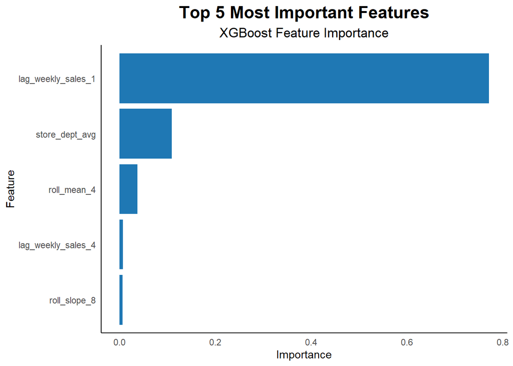

```r
#====== Plot final model feature importance ======

feature_importance_plot <- extract_fit_engine(final_model_fit) %>%
  vip(num_features = 5) + ##top 5 features

  geom_col(fill = "#1F78B4") +

  #---- add titles and axis labels ----
  labs(
    title = "Top 5 Most Important Features",
    subtitle = "XGBoost Feature Importance",
    x = "Feature",
    y = "Importance"
    ) +

  #---- aesthetic changes to plot ----
  theme_minimal(base_size = 11) +
  theme(

    panel.grid = element_blank(),

    plot.title = element_text(hjust = 0.5, face = "bold", size = 17),

    plot.subtitle = element_text(hjust = 0.5, size = 13),

    axis.line = element_line(color = "black", linewidth = 0.4),

    legend.position = "none"

    )

feature_importance_plot
```

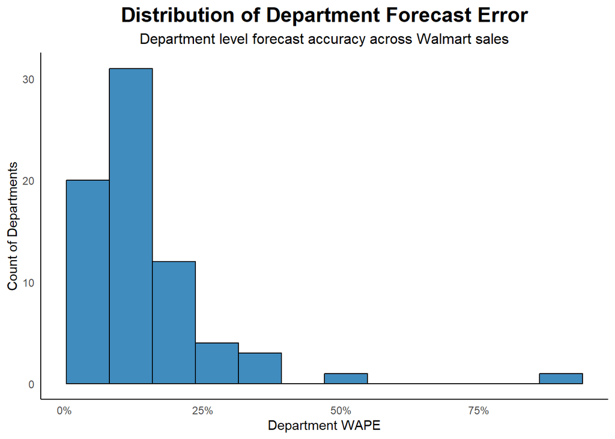

```r
#====== Aggregate true and estimated demand to total weekly level ======

predictions_plot_tbl <- final_test_predictions %>%
  ##can safely bind week_dates since predict() function preserves order of original test data
  bind_cols(test_tbl %>% select(week_dates)) %>%
  group_by(week_dates) %>%
  summarise(

    truth = sum(weekly_sales),
    estimation = sum(.pred),
    .groups = "drop"

  )





#====== Filter out extreme department WAPE values ======

dept_model_evaluation_filtered <- dept_model_evaluation %>%
  filter(.estimate < 1)





#====== Plot distribution of department WAPE ======

dept_wape_distribution_plot <- ggplot(dept_model_evaluation_filtered, aes(x = .estimate)) +

  #---- specify histogram ----
  geom_histogram(
    bins = 12,
    fill = "#1F78B4",
    color = "black",
    alpha = 0.85
  ) +

  #---- add titles and labels ----
  labs(
    title = "Distribution of Department Forecast Error",
    subtitle = "Department level forecast accuracy across Walmart sales",
    x = "Department WAPE",
    y = "Count of Departments"
  ) +

  #---- format x axis as percentages ----
  scale_x_continuous(labels = percent_format(accuracy = 1)) +

  #---- aesthetic changes to plot ----
  theme_minimal(base_size = 11) +

  theme(

    panel.grid = element_blank(),

    plot.title = element_text(
      hjust = 0.5,
      face = "bold",
      size = 17
    ),

    plot.subtitle = element_text(
      hjust = 0.5,
      size = 12
    ),

    axis.line = element_line(
      color = "black",
      linewidth = 0.4
    )

    )

dept_wape_distribution_plot
```

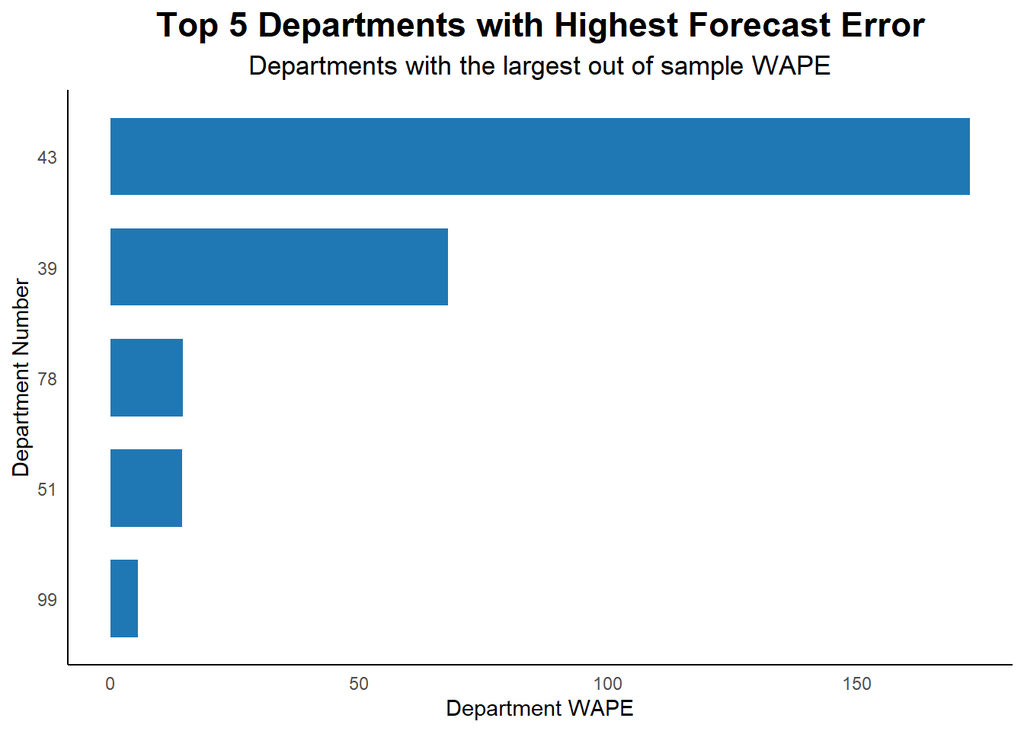

```r
#====== Save distribution of department WAPE plot ======

ggsave("dept_wape_distribution_plot.png", dept_wape_distribution_plot, width = 10, height = 6, dpi = 200)





#====== Pull most difficult departments to forecast ======

difficult_depts_tbl <- dept_model_evaluation %>%
  arrange(desc(.estimate)) %>%
  slice_head(n = 5) %>%
  mutate(dept = reorder(as.factor(dept), .estimate))





#====== Plot most difficult departments to forecast ======

difficult_depts_plot <- ggplot(difficult_depts_tbl, aes(x = dept, y = .estimate)) +

  geom_col(
    fill = "#1F78B4",
    width = 0.7
  ) +

  coord_flip() + #swap x axis and y axis

  #---- add titles and labels ----
  labs(
    title = "Top 5 Departments with Highest Forecast Error",
    subtitle = "Departments with the largest out of sample WAPE",
    x = "Department Number",
    y = "Department WAPE"
  ) +

  #---- aesthetic changes ----
  theme_minimal(base_size = 11) +

  theme(

    panel.grid = element_blank(),

    plot.title = element_text(
      hjust = 0.5,
      face = "bold",
      size = 17),

    plot.subtitle = element_text(
      hjust = 0.5,
      size = 13
    ),

    axis.line = element_line(
      color = "black",
      linewidth = 0.4
    )

  )

difficult_depts_plot
```

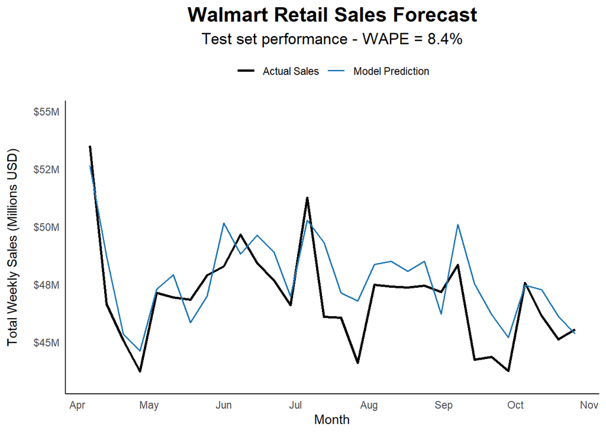

```r
#====== Plot true vs estimated demand ======

predictions_plot <- ggplot(predictions_plot_tbl, aes(x = week_dates)) +

  #---- add truth and prediction lines on plot ----
  geom_line(aes(y = truth, color = "Actual Sales"), linewidth = 0.9) +
  geom_line(aes(y = estimation, color = "Model Prediction"), linewidth = 0.7) +

  #---- add titles and axis labels ----
  labs(
    title = "Walmart Retail Sales Forecast",
    subtitle = "Test set performance - WAPE = 8.4%",
    y = "Total Weekly Sales (Millions USD)",
    x = "Month",
    color = NULL
  ) +

  #---- specify line colors ----
  scale_color_manual(
    values = c(
    "Actual Sales" = "black",
    "Model Prediction" = "#1F78B4"
    )
    ) +

  #---- transformations to y axis values ----
  scale_y_continuous(
    labels = label_dollar(scale = 1e-6, accuracy = 1, suffix = "M"),
    expand = expansion(mult = c(0.1, 0.2))
    ) +

  #---- transformations to x axis values ----
  scale_x_date(date_breaks = "1 month", date_labels = "%b") +

  #---- aesthetic changes to plot ----
  theme_minimal(base_size = 11) +
  theme(

    panel.grid = element_blank(),

    plot.title = element_text(
      hjust = 0.5,
      face = "bold",
      size = 17
      ),

    plot.subtitle = element_text(
      hjust = 0.5,
      size = 13
      ),

    axis.line = element_line(
      color = "black",
      linewidth = 0.4
      ),

    axis.title.y = element_text(margin = margin(r = 12)),

    legend.position = "top"

    )


predictions_plot
```

```r
#====== Save predictions plot ======

ggsave("predictions_plot.png", predictions_plot, width = 10, height = 6, dpi = 200)
```